# White wine quality by Sumit Kumar Mahato

# Univariate Analysis

The guiding question of the analysis is which physicochemicals have significant impact on the quality of the wines.

# Univariate Plots Section

```
## 'data.frame':    4898 obs. of  13 variables:
##  $ X                   : int  1 2 3 4 5 6 7 8 9 10 ...
##  $ fixed.acidity       : num  7 6.3 8.1 7.2 7.2 8.1 6.2 7 6.3 8.1 ...
##  $ volatile.acidity    : num  0.27 0.3 0.28 0.23 0.23 0.28 0.32 0.27 0.3 0.22 ...
##  $ citric.acid         : num  0.36 0.34 0.4 0.32 0.32 0.4 0.16 0.36 0.34 0.43 ...
##  $ residual.sugar      : num  20.7 1.6 6.9 8.5 8.5 6.9 7 20.7 1.6 1.5 ...
##  $ chlorides           : num  0.045 0.049 0.05 0.058 0.058 0.05 0.045 0.045 0.049 0.044 ...
##  $ free.sulfur.dioxide : num  45 14 30 47 47 30 30 45 14 28 ...
##  $ total.sulfur.dioxide: num  170 132 97 186 186 97 136 170 132 129 ...
##  $ density             : num  1.001 0.994 0.995 0.996 0.996 ...
##  $ pH                  : num  3 3.3 3.26 3.19 3.19 3.26 3.18 3 3.3 3.22 ...
##  $ sulphates           : num  0.45 0.49 0.44 0.4 0.4 0.44 0.47 0.45 0.49 0.45 ...
##  $ alcohol             : num  8.8 9.5 10.1 9.9 9.9 10.1 9.6 8.8 9.5 11 ...
##  $ quality             : int  6 6 6 6 6 6 6 6 6 6 ...
```

```
##        X        fixed.acidity    volatile.acidity  citric.acid
##  Min.   :   1   Min.   : 3.800   Min.   :0.0800   Min.   :0.0000
##  1st Qu.:1225   1st Qu.: 6.300   1st Qu.:0.2100   1st Qu.:0.2700
##  Median :2450   Median : 6.800   Median :0.2600   Median :0.3200
##  Mean   :2450   Mean   : 6.855   Mean   :0.2782   Mean   :0.3342
##  3rd Qu.:3674   3rd Qu.: 7.300   3rd Qu.:0.3200   3rd Qu.:0.3900
##  Max.   :4898   Max.   :14.200   Max.   :1.1000   Max.   :1.6600
##  residual.sugar     chlorides       free.sulfur.dioxide
##  Min.   : 0.600   Min.   :0.00900   Min.   :  2.00
##  1st Qu.: 1.700   1st Qu.:0.03600   1st Qu.: 23.00
##  Median : 5.200   Median :0.04300   Median : 34.00
##  Mean   : 6.391   Mean   :0.04577   Mean   : 35.31
##  3rd Qu.: 9.900   3rd Qu.:0.05000   3rd Qu.: 46.00
##  Max.   :65.800   Max.   :0.34600   Max.   :289.00
##  total.sulfur.dioxide    density             pH          sulphates
##  Min.   :  9.0        Min.   :0.9871   Min.   :2.720   Min.   :0.2200
##  1st Qu.:108.0        1st Qu.:0.9917   1st Qu.:3.090   1st Qu.:0.4100
##  Median :134.0        Median :0.9937   Median :3.180   Median :0.4700
##  Mean   :138.4        Mean   :0.9940   Mean   :3.188   Mean   :0.4898
##  3rd Qu.:167.0        3rd Qu.:0.9961   3rd Qu.:3.280   3rd Qu.:0.5500
##  Max.   :440.0        Max.   :1.0390   Max.   :3.820   Max.   :1.0800
##     alcohol         quality
##  Min.   : 8.00   Min.   :3.000
##  1st Qu.: 9.50   1st Qu.:5.000
##  Median :10.40   Median :6.000
##  Mean   :10.51   Mean   :5.878
##  3rd Qu.:11.40   3rd Qu.:6.000
##  Max.   :14.20   Max.   :9.000
```

### What is the structure of your dataset?

The dataset consists of 13 variables and approximately 5000 observations.All the variables are either int or num datatype. Summary statistics doesn’t help in distribution of data and identifying patterns. So in the next section the distribution of each feature is plotted.

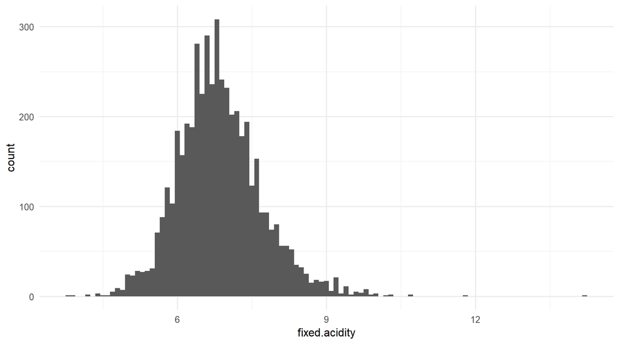

The fixed acidity seems to be centered with some outliers to the right. The bin width has been reduced to get more details into the distribution

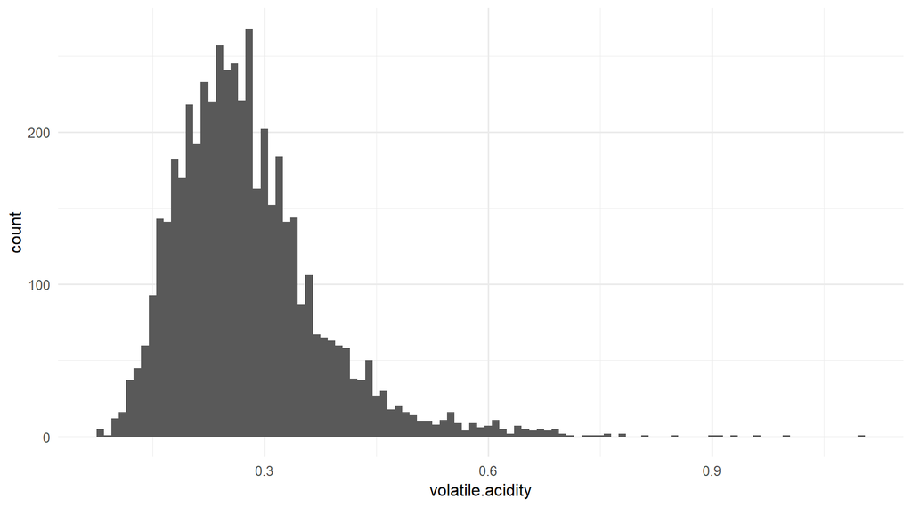

The volatile acidity is slightly skewed to the right with few outliers.

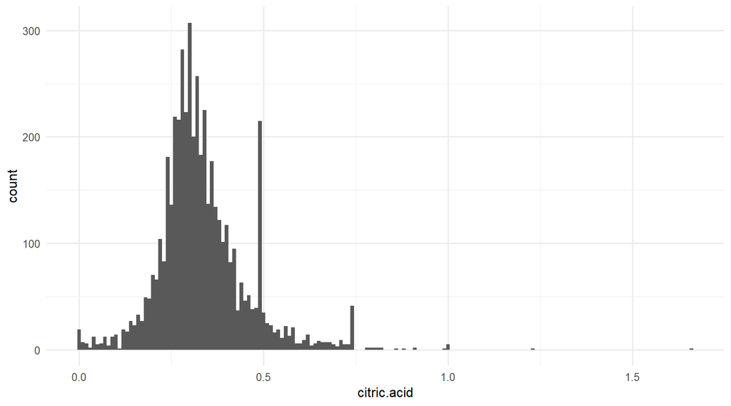

The distribution of citric acid looks centred with few outliers to the right. With a binwidth of 0.01 we can see that there are quite a few wines at citric acid =0.5 which is quite unlikely.

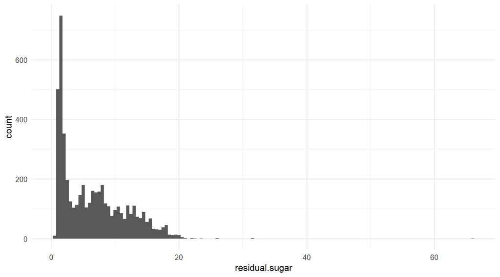

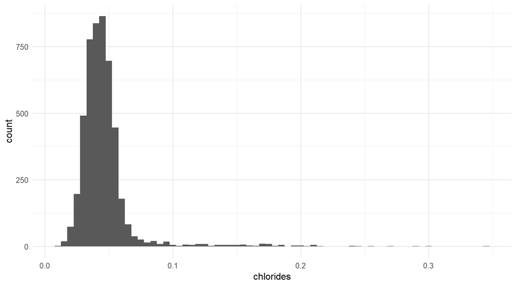

The distribution of chlorides is skewed to the right with significant number of chlorides.

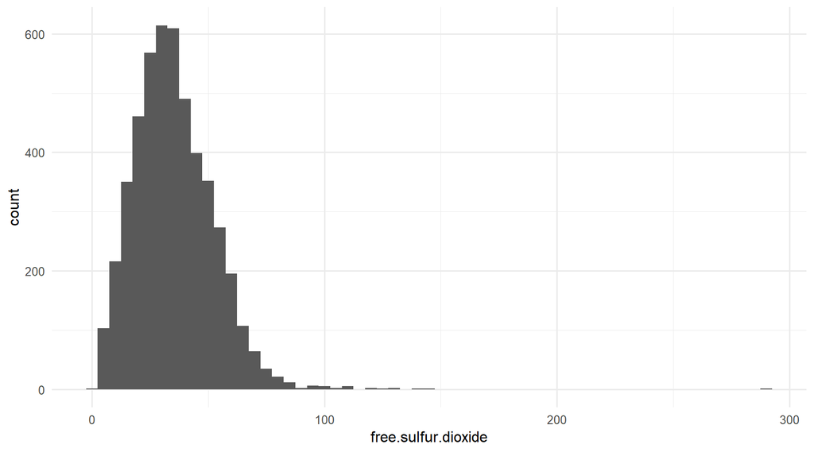

The plot is centred around 40 with few outliers to the right.

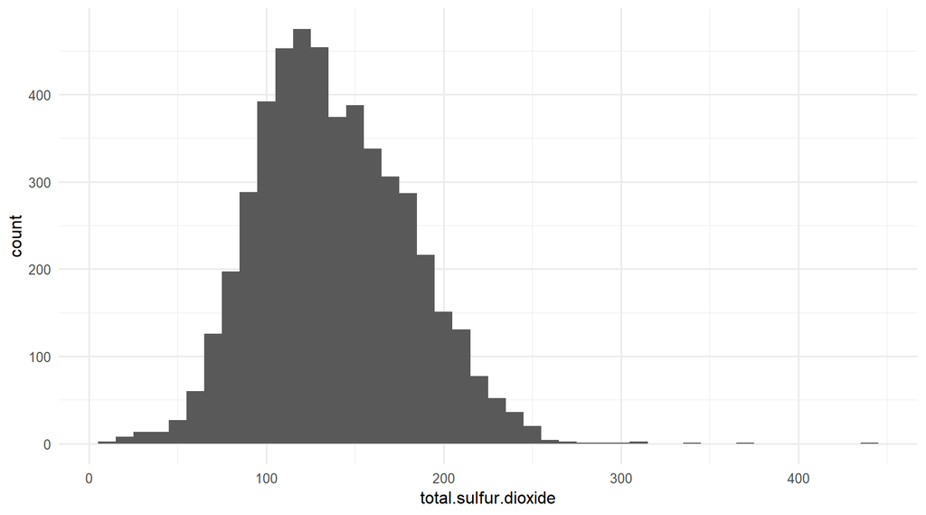

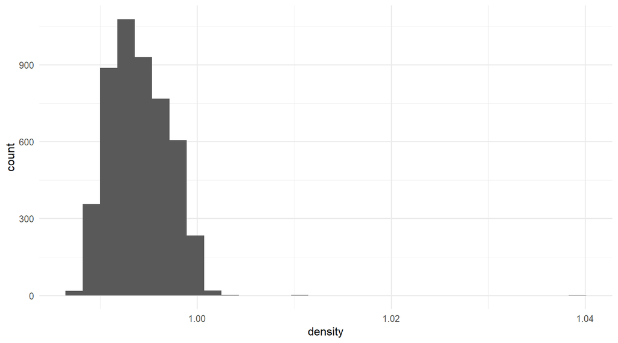

Most of the wines have density in the range of 0.98-1.00. In future, we will explore the variations in density and how it is related to other physicochemical features.

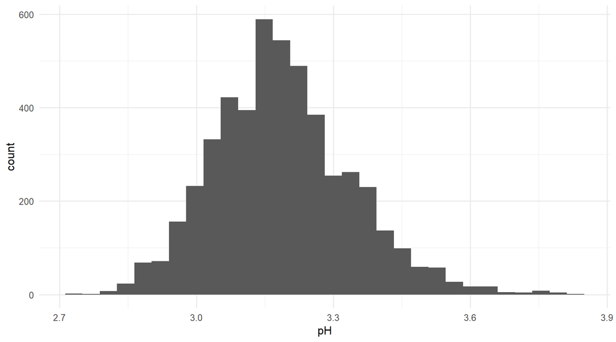

pH values show that all white wines are acidic in nature and is quite normally distributed.

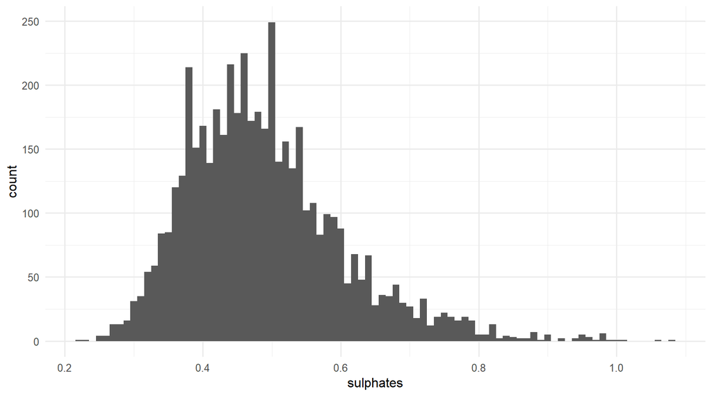

The distribution of sulphates seem to be quite normally distributed however it has quite a few outliers to the right.

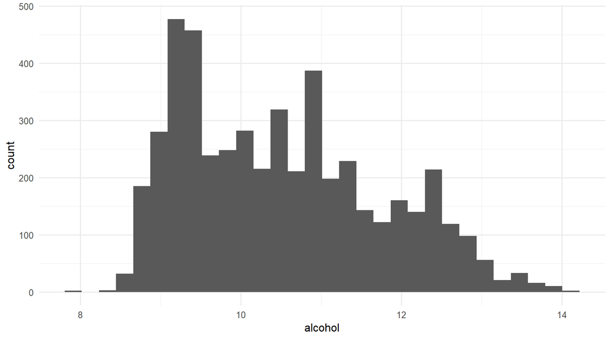

The bulk of the data seems to be distributed b/w 9-13 % of alcohol with no outliers.

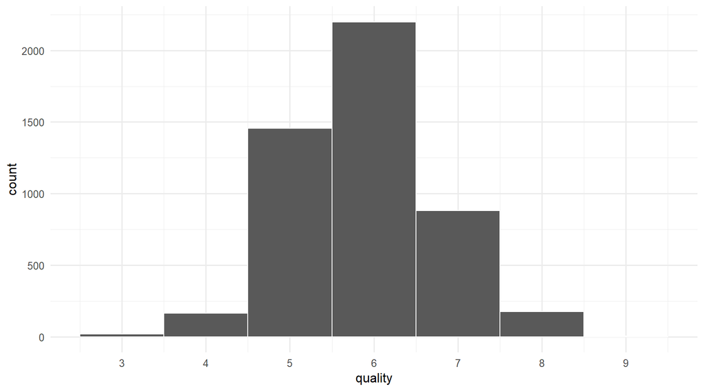

From the above plots we can say that most of the values are centered and quite a few of them have outliers. The histogram quality shows that it has discrete values and could e treated as a factor for future analysis.

### What is/are the main feature(s) of interest in your dataset?

The main feature of interest in the dataset is the quality of wines.

### What other features in the dataset do you think will help support your investigation into your feature(s) of interest?

11 physicochemical features are responsible for the quality of the wine. I am guessing that the features which are responsible for the taste, smell or after-effect of a wine could impact the quality score of the wine. Volatile acidity, citric acid, residual sugar, free sulfur dioxide, and alcohol are the features in the textfile on the dataset. In the next section the correlation of every feature against quality is estimated.

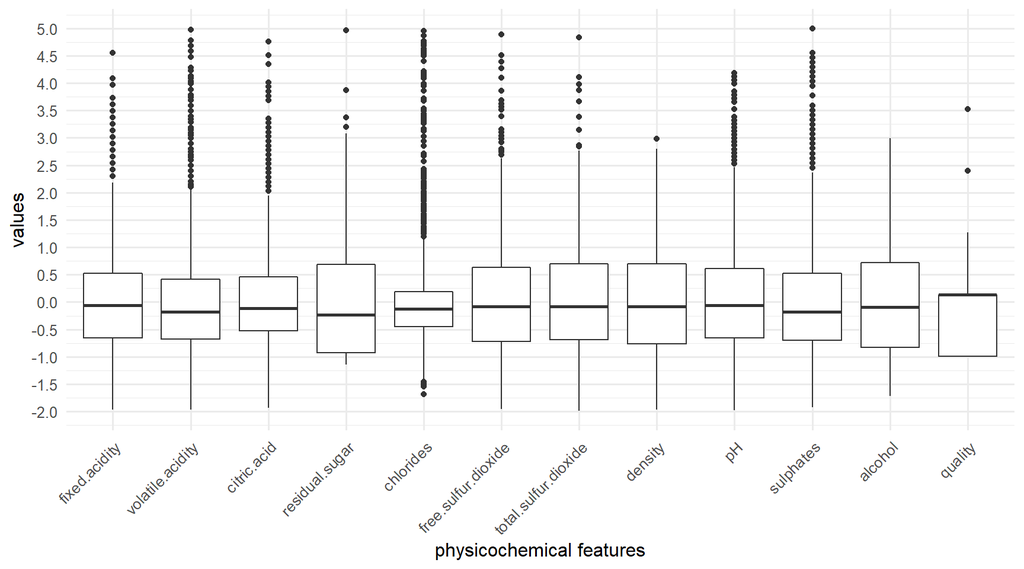

It would be worthwhile to see the spread of individual variables and how they compare with each other. Therefore, the following boxplot is presented in a normalized scale since the units of each value was different.

### Did you create any new variables from existing variables in the dataset?

No.

### Of the features you investigated, were there any unusual distributions? Did you perform any operations on the data to tidy, adjust, or change the form of the data? If so, why did you do this?

It can be noted that the chlorides had the lowest spread of data and alcohol has no outliers (is it regulated?)

# Bivariate Analysis

There are around 12 features in the dataset and it would be impractical to analyse all the relationship in details. Therefore, a combined bivariate plot is plotted for all the variables using ggpairs. From this plot the variables having strong correlation are further explored in the upcoming sections.

# Bivariate Plots Section

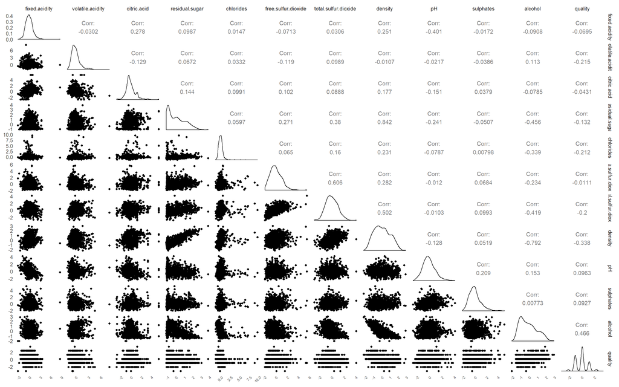

From the above plot we can see that there is a strong correlation b/w density and residual sugar, and alcohol and density. We also see moderate correlations b/w quality and volatile acidity, residual sugar, chloride, Total sulfur dioxide, density, and alcohol. These correlations are explored in the next sections.

### Talk about some of the relationships you observed in this part of the investigation. How did the feature(s) of interest vary with other features in the dataset?

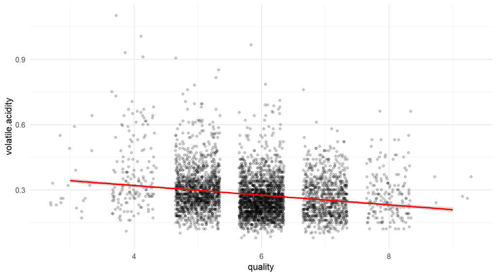

As noted volatile acidity has negative correlation with quality.

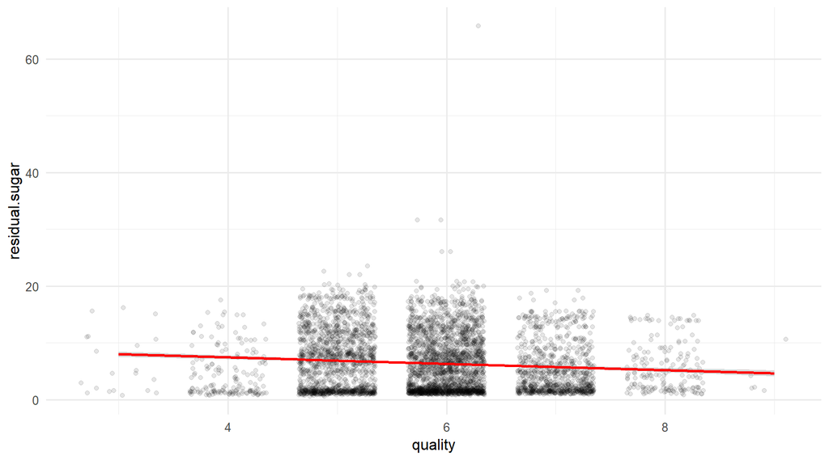

It is noted that most of the high quality wines (8-9) are less sweet and has sugar content in the range of 1-10.

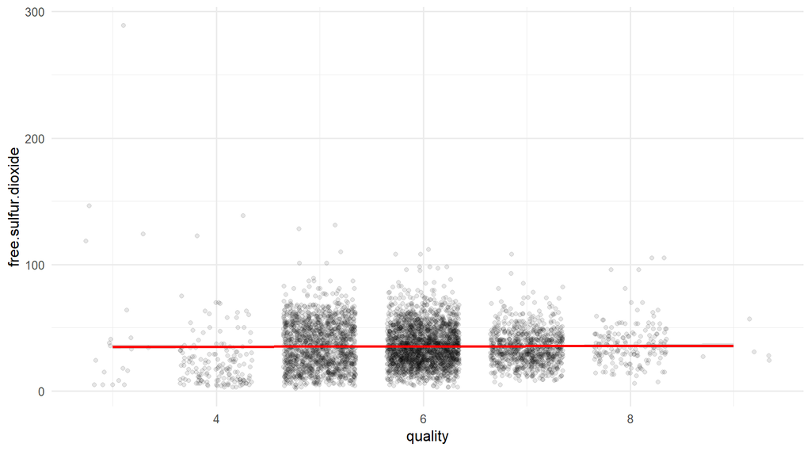

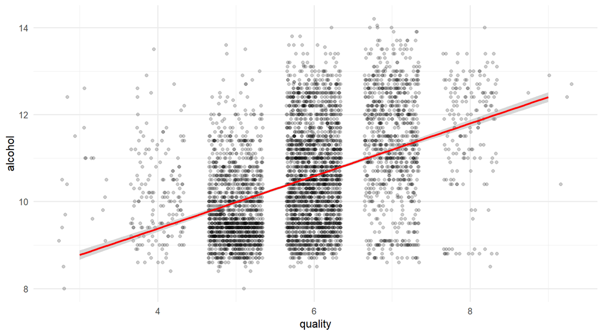

Alcohol content had a positive effect on the quality of wine(0.467) which was expected however, the negative correlation of density and quality was interesting which implied dense wines are less preferred. It would be interesting to note the impact of the interacting features on quality which would be carried out in the next section.

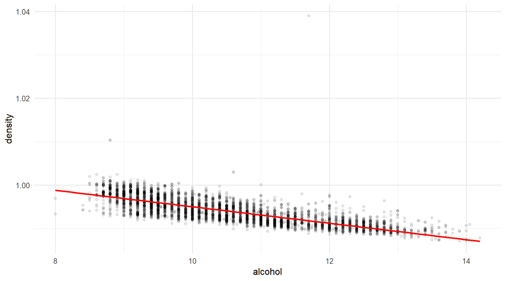

Strong relationship is noted between the alcohol and density which is a negative one (-0.792). The reason could be the lower density of alcohol as compared to water so higher the alcohol content in a wine lower would be the density of the wine.

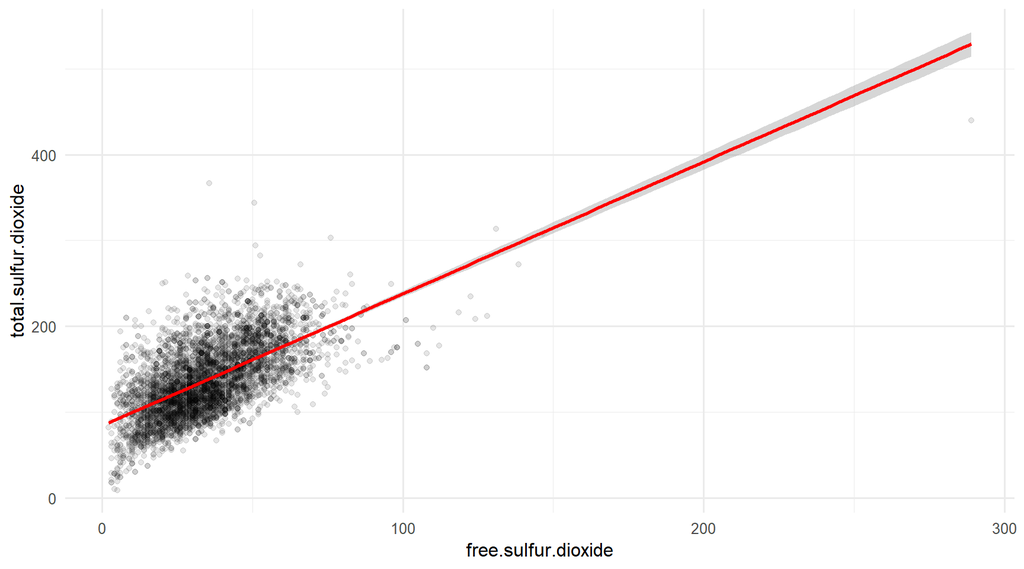

The total sulphur dioxide and the free sulphur dioxide has a moderate corelation of 0.6 which is justified as the latter is a constituent of the former.

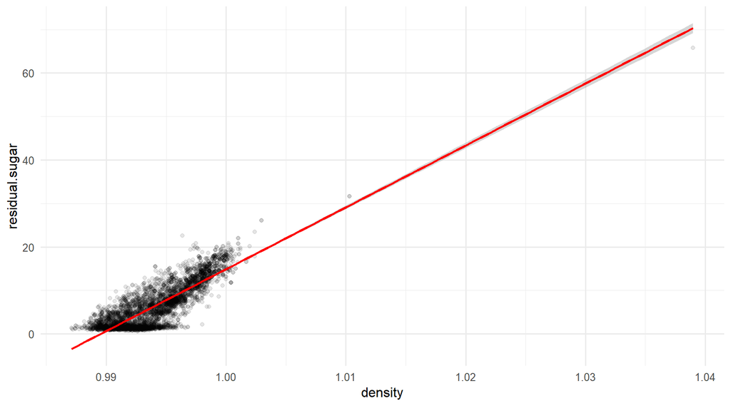

### What was the strongest relationship you found?

The strongest relationship is found between density and residual sugar (0.842).

# Multivariate Analysis

In this section the effect of alcohol on quality is analysed in conjuction with other features which are correlated to quality (cor>0.1) either positively or negatively.

2 types of plots are made for the input and output features in which the first plot has quality encoded as color and second one has quality faceted. The color encoded plots show us the spread of physicochemical properties for different qualities of wine. On the other hand when quality is faceted we have clearer details on quality of wines.

# Multivariate Plots Section

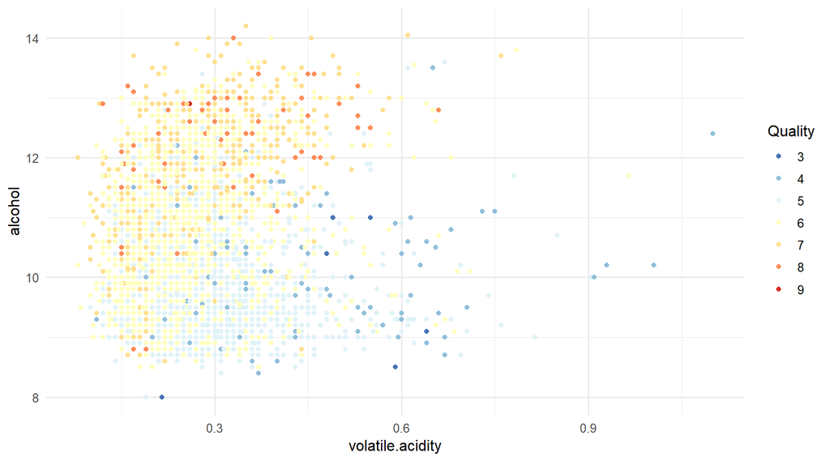

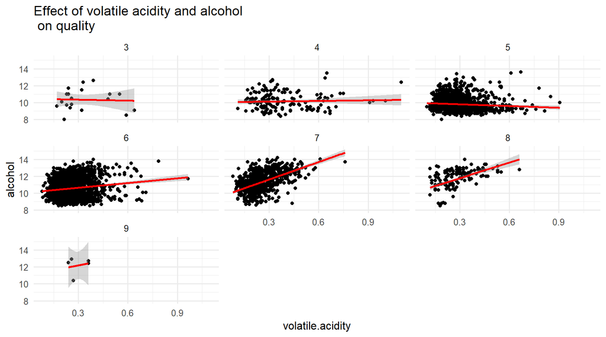

The plot with quality encoded as color shows that most of the wines with quality 6-9 are within 0.2-0.4. However, it is interesting to note that some wines with volatile acidity >0.4 are either very high quality or very poor based on their alcohol content. This fact is further elaborated in the next plot.

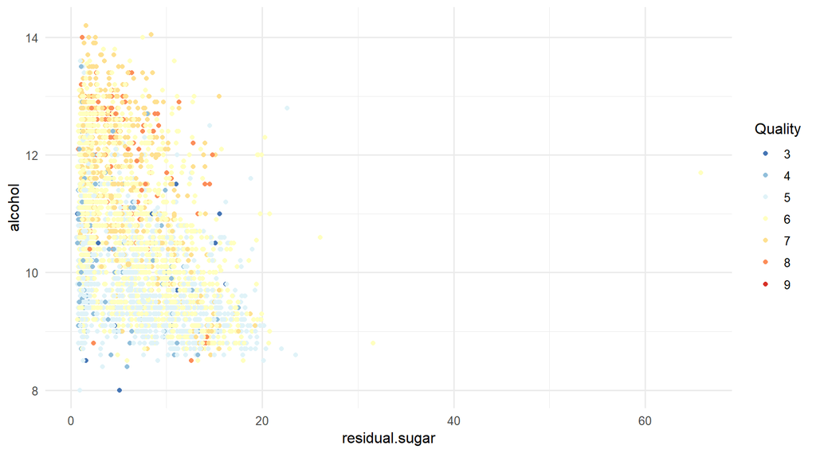

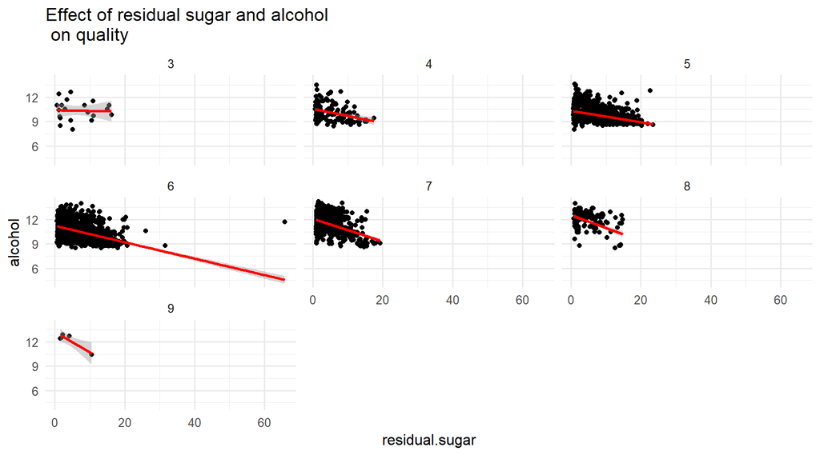

In the above 2 plots it is again justified that alcohol content drives the quailty of wine. However, we can see few outliers to this theory, since we see some wine of very high quality with high sugar and low alcohol. This leads to a downward trend in the quality faceted plot. One possible reason for this could be judges with liking for sweet wine rating the wines.

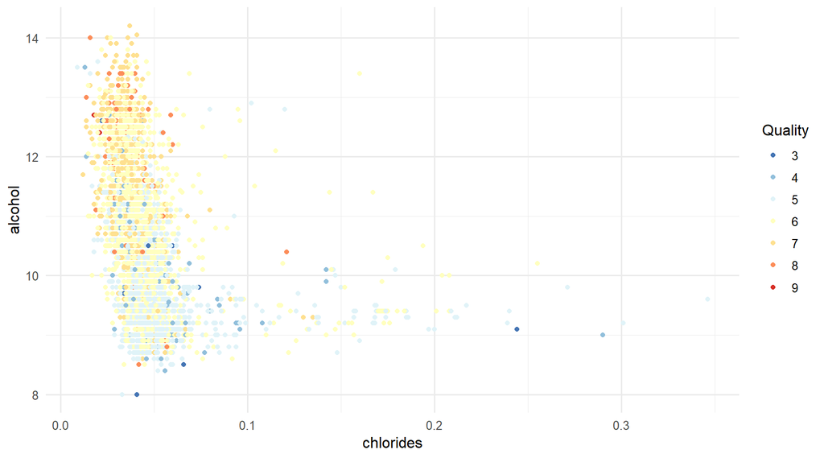

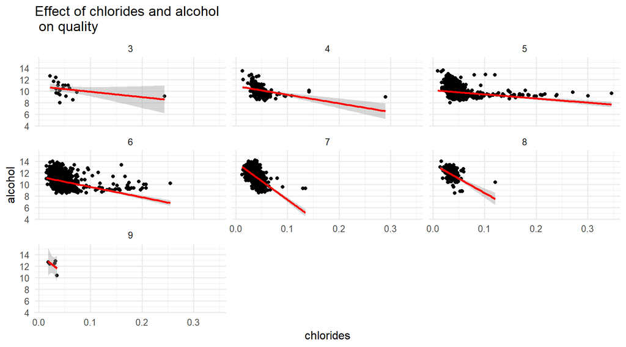

The variation in chloride content is low and is basically limited around 0.05. We can see that higher alcohol content leads to higher rating. Some wines with higher chlorides are of poor quality.

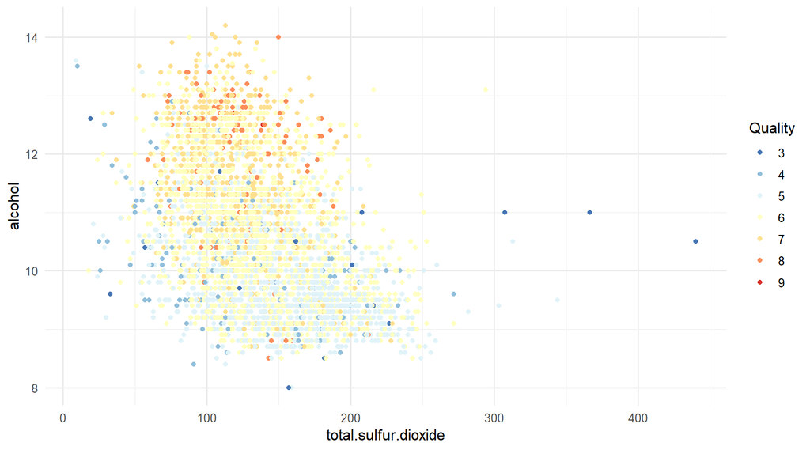

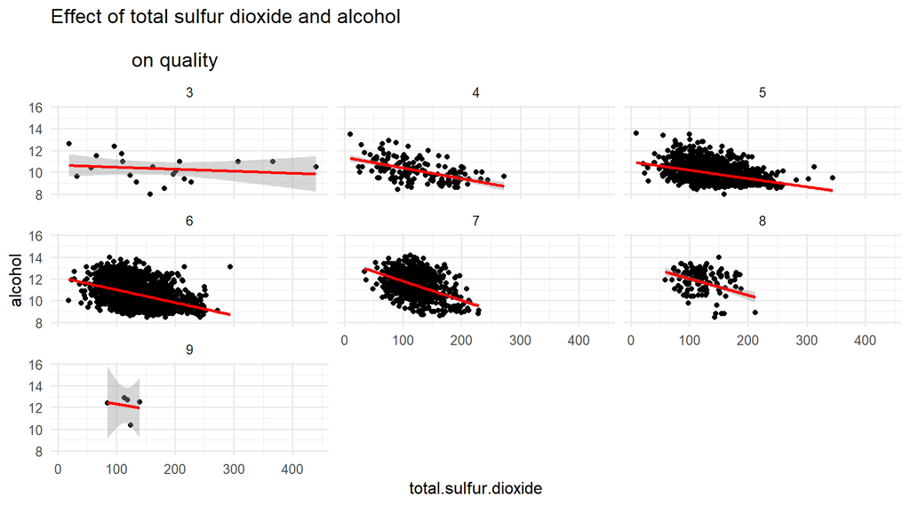

The Sulfur dioxide content is spread across a wide range from 50-200 and a clear trend is visible–higher the alcohol, higher the quality. Some outliers outside the given SO2 range are of very poor quality.

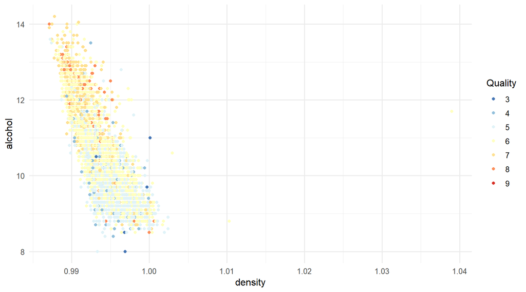